# Tipología y ciclo de vida de los datos: Práctica 2

### 5.4.2 Regresión logística sobre imputación mediana

Se replica ahora el análisis con datos perdidos imputados por la mediana.

#### 5.4.2.1 Regresión logística, imputación mediana, datos no transformados

```r
train_log<-train_median
test_log<-test_median
train_log$class[train_log$class=="neg"]<-"0"
train_log$class[train_log$class=="pos"]<-"1"
train_log$class<-as.factor(train_log$class)
levels(train_log$class)<- c('neg', 'pos')

summary(train_log$class)
```

```
##   neg   pos
## 58650   996
```

```r
library(caret)

model_log1 <- glm (class~., data=train_log, family = binomial)
summary(model_log1)
```

```
##
## Call:
## glm(formula = class ~ ., family = binomial, data = train_log)
##
## Deviance Residuals:
##     Min       1Q   Median       3Q      Max
## -4.6759  -0.0816  -0.0621  -0.0563   4.0354
##
## Coefficients:
##               Estimate Std. Error z value Pr(>|z|)
## (Intercept) -6.440e+00  1.333e-01 -48.325  < 2e-16 ***
## aa_000       4.993e-06  7.023e-07   7.109 1.17e-12 ***
## ac_000      -3.699e-10  1.383e-10  -2.675 0.007474 **
## ag_000      -8.488e-06  2.254e-05  -0.377 0.706492
## ag_002      -8.751e-07  3.609e-07  -2.425 0.015315 *
## ag_004      -1.274e-06  2.338e-07  -5.451 5.02e-08 ***
## ag_005      -1.166e-06  1.957e-07  -5.959 2.55e-09 ***
## ag_006      -1.099e-06  1.995e-07  -5.506 3.67e-08 ***
## ag_007      -1.242e-06  2.030e-07  -6.117 9.52e-10 ***
## ag_008      -1.265e-06  3.111e-07  -4.067 4.77e-05 ***
## ag_009      -1.297e-06  2.791e-07  -4.647 3.37e-06 ***
## aj_000      -1.681e-06  4.870e-07  -3.452 0.000557 ***
## al_000       2.005e-07  3.248e-07   0.617 0.537026
## am_0         2.560e-09  2.194e-07   0.012 0.990691
## an_000       1.525e-07  7.973e-08   1.913 0.055719 .
## ao_000      -1.821e-07  8.895e-08  -2.048 0.040592 *
## ap_000      -2.605e-07  2.040e-07  -1.277 0.201592
## aq_000       5.820e-07  1.356e-07   4.291 1.78e-05 ***
## ar_000       3.312e-03  3.440e-03   0.963 0.335745
## as_000       8.016e-07  1.777e-06   0.451 0.651875
## at_000       9.333e-07  3.836e-07   2.433 0.014962 *
## au_000       3.046e-06  3.046e-06   1.000 0.317276
## av_000       1.978e-05  7.411e-06   2.669 0.007605 **
## ax_000      -1.308e-04  5.024e-05  -2.603 0.009253 **
## ay_000      -8.091e-05  7.990e-05  -1.013 0.311222
## ay_001      -8.099e-05  7.990e-05  -1.014 0.310737
## ay_002      -8.075e-05  7.990e-05  -1.011 0.312150
## ay_003      -8.128e-05  7.990e-05  -1.017 0.309003
## ay_004      -8.116e-05  7.990e-05  -1.016 0.309739
## ay_005      -8.104e-05  7.990e-05  -1.014 0.310418
```

[output cut: 94 more lines]

```
## ee_007      -1.707e-04  1.205e-04  -1.416 0.156850
## ee_008      -1.702e-04  1.205e-04  -1.412 0.157995
## ee_009      -1.719e-04  1.205e-04  -1.426 0.153953
## ef_000      -1.101e-02  2.191e-02  -0.503 0.615190
## eg_000       1.779e-03  4.282e-03   0.415 0.677831
## ---
## Signif. codes:  0 '***' 0.001 '**' 0.01 '*' 0.05 '.' 0.1 ' ' 1
##
## (Dispersion parameter for binomial family taken to be 1)
##
##     Null deviance: 10127.4  on 59645  degrees of freedom
## Residual deviance:  3216.6  on 59517  degrees of freedom
## AIC: 3474.6
##
## Number of Fisher Scoring iterations: 18
```

```r
# Mostrar las variables significativas (p<0.05)
sig_coeff<-data.frame(summary(model_log1)$coef[summary(model_log1)$coef[,4] <= .05,c(4)])
names(sig_coeff)<-c("p_value")
dim(sig_coeff)[1]
```

```
## [1] 37
```

```r
rownames(sig_coeff)
```

```
##  [1] "(Intercept)" "aa_000"      "ac_000"      "ag_002"      "ag_004"
##  [6] "ag_005"      "ag_006"      "ag_007"      "ag_008"      "ag_009"
## [11] "aj_000"      "ao_000"      "aq_000"      "at_000"      "av_000"
## [16] "ax_000"      "ba_003"      "bf_000"      "bh_000"      "bu_000"
## [21] "ca_000"      "cj_000"      "ck_000"      "cl_000"      "cm_000"
## [26] "cq_000"      "dd_000"      "dg_000"      "di_000"      "dk_000"
## [31] "do_000"      "dt_000"      "dv_000"      "dx_000"      "eb_000"
## [36] "ec_00"       "ed_000"
```

```r
## Predicción de valores
predict <- predict(model_log1, test_log, type = 'response')

## Matriz de confusión
cm<-table(test_log$class, predict > 0.5)
cm
```

```
##
##       FALSE  TRUE
##   neg 15579    46
##   pos   133   242
```

```r
precision<-(cm[1,1]+cm[2,2])/sum(cm);precision
```

```
## [1] 0.9888125
```

```r
## Coste Total
coste_total_log <- cm[1,2]*10 + cm[2,1]*500
coste_total_log
```

```
## [1] 66960
```

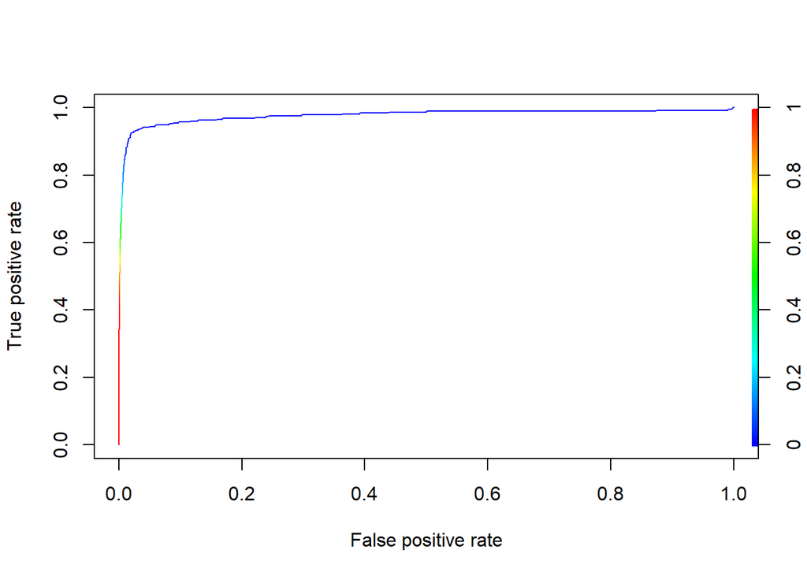

```r
#ROCR Curve
library(ROCR)
ROCRpred <- prediction(predict, test_log$class)
ROCRperf <- performance(ROCRpred, 'tpr','fpr')
plot(ROCRperf, colorize = TRUE, text.adj = c(-0.2,1.7))
```

```r
# AUC value
auc_ROCR <- performance(ROCRpred, measure = "auc")
auc_ROCR <- auc_ROCR@y.values[[1]];auc_ROCR
```

```
## [1] 0.9765557
```

#### 5.4.2.2 Regresión logística, imputación mediana, datos transformados Box-Cox

```r
train_log<-train_bc_median
test_log<-test_bc_median
train_log$class[train_log$class=="neg"]<-"0"
train_log$class[train_log$class=="pos"]<-"1"
train_log$class<-as.factor(train_log$class)
levels(train_log$class)<- c('neg', 'pos')

summary(train_log$class)
```

```
##   neg   pos
## 58650   996
```

```r
prop.table(table(train_log$class))
```

```
##
##        neg        pos
## 0.98330148 0.01669852
```

```r
table(train_log$class)
```

```
##
##   neg   pos
## 58650   996
```

```r
library(caret)

model_log1 <- glm (class~., data=train_log, family = binomial)
summary(model_log1)
```

```
##
## Call:
## glm(formula = class ~ ., family = binomial, data = train_log)
##
## Deviance Residuals:
##     Min       1Q   Median       3Q      Max
## -3.3695  -0.0401  -0.0155  -0.0004   6.6093
##
## Coefficients:
##               Estimate Std. Error z value Pr(>|z|)
## (Intercept) -3.430e+01  1.984e+00 -17.284  < 2e-16 ***
## aa_000       3.142e-01  1.108e-01   2.836 0.004572 **
## ac_000      -1.741e-02  2.297e-02  -0.758 0.448326
## ag_000       4.342e-02  5.839e-02   0.744 0.457088
## ag_002       1.527e-02  3.107e-02   0.491 0.623164
## ag_004      -2.175e-01  9.109e-02  -2.387 0.016976 *
## ag_005      -5.531e-02  1.510e-01  -0.366 0.714158
## ag_006      -1.601e-01  1.576e-01  -1.016 0.309659
## ag_007      -9.659e-02  7.809e-02  -1.237 0.216126
## ag_008      -9.976e-03  3.983e-02  -0.251 0.802200
## ag_009      -5.414e-02  2.120e-02  -2.553 0.010665 *
## aj_000       9.874e-03  2.012e-02   0.491 0.623601
## al_000      -1.023e-01  7.190e-02  -1.423 0.154803
## am_0         9.869e-02  6.582e-02   1.499 0.133795
## an_000       8.538e-01  5.715e-01   1.494 0.135225
## ao_000       6.774e-01  3.077e-01   2.201 0.027713 *
## ap_000       2.704e+00  4.367e-01   6.192 5.95e-10 ***
## aq_000       1.729e+00  3.111e-01   5.558 2.73e-08 ***
## ar_000      -9.365e-02  8.483e-02  -1.104 0.269633
## as_000       2.049e-02  7.151e-02   0.287 0.774435
## at_000      -4.133e-02  1.935e-02  -2.136 0.032701 *
## au_000       6.422e-02  6.218e-02   1.033 0.301632
## av_000       4.863e-01  9.417e-02   5.163 2.42e-07 ***
## ax_000      -5.077e-01  1.084e-01  -4.684 2.81e-06 ***
## ay_000       2.414e-01  5.665e-02   4.262 2.03e-05 ***
## ay_001      -2.563e-01  9.729e-02  -2.635 0.008417 **
## ay_002       3.329e-01  9.224e-02   3.609 0.000308 ***
## ay_003      -1.442e-01  5.498e-02  -2.622 0.008740 **
## ay_004       7.587e-02  2.435e-02   3.115 0.001839 **
## ay_005       1.448e-02  1.935e-02   0.748 0.454369
```

[output cut: 94 more lines]

```
## ee_007      -5.011e-01  7.105e-02  -7.052 1.76e-12 ***
## ee_008       2.822e-01  6.106e-02   4.621 3.81e-06 ***
## ee_009      -3.773e-02  2.779e-02  -1.358 0.174583
## ef_000       8.942e-02  4.245e-01   0.211 0.833185
## eg_000      -1.143e-01  3.361e-01  -0.340 0.733831
## ---
## Signif. codes:  0 '***' 0.001 '**' 0.01 '*' 0.05 '.' 0.1 ' ' 1
##
## (Dispersion parameter for binomial family taken to be 1)
##
##     Null deviance: 10127.4  on 59645  degrees of freedom
## Residual deviance:  2642.9  on 59517  degrees of freedom
## AIC: 2900.9
##
## Number of Fisher Scoring iterations: 13
```

```r
# Mostrar las variables significativas (p<0.05)
sig_coeff<-data.frame(summary(model_log1)$coef[summary(model_log1)$coef[,4] <= .05,c(4)])
names(sig_coeff)<-c("p_value")
dim(sig_coeff)[1]
```

```
## [1] 51
```

```r
rownames(sig_coeff)
```

```
##  [1] "(Intercept)" "aa_000"      "ag_004"      "ag_009"      "ao_000"
##  [6] "ap_000"      "aq_000"      "at_000"      "av_000"      "ax_000"
## [11] "ay_000"      "ay_001"      "ay_002"      "ay_003"      "ay_004"
## [16] "ay_006"      "ay_008"      "ay_009"      "ba_002"      "ba_008"
## [21] "bc_000"      "bd_000"      "be_000"      "bg_000"      "bh_000"
## [26] "bi_000"      "bj_000"      "bu_000"      "bx_000"      "ci_000"
## [31] "cl_000"      "cm_000"      "cn_000"      "cn_002"      "cn_004"
## [36] "cn_009"      "cq_000"      "cs_000"      "cs_004"      "dg_000"
## [41] "dh_000"      "di_000"      "dn_000"      "dr_000"      "ec_00"
## [46] "ed_000"      "ee_004"      "ee_005"      "ee_006"      "ee_007"
## [51] "ee_008"
```

```r
## Predicción de valores
predict <- predict(model_log1, test_log, type = 'response')

## Matriz de confusión
cm<-table(test_log$class, predict > 0.5)
cm
```

```
##
##       FALSE  TRUE
##   neg 15581    44
##   pos   127   248
```

```r
precision<-(cm[1,1]+cm[2,2])/sum(cm);precision
```

```
## [1] 0.9893125
```

```r
## Coste Total
coste_total_log <- cm[1,2]*10 + cm[2,1]*500
coste_total_log
```

```
## [1] 63940
```

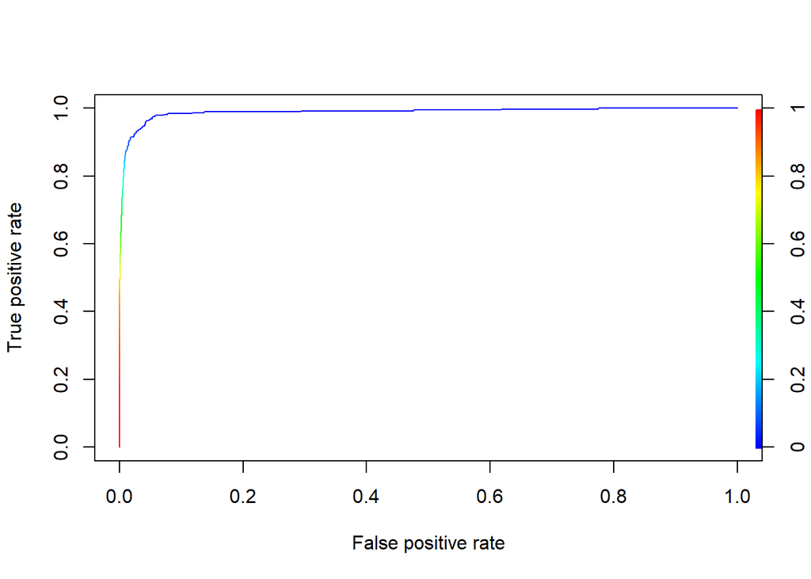

```r
#ROCR Curve
library(ROCR)
ROCRpred <- prediction(predict, test_log$class)
ROCRperf <- performance(ROCRpred, 'tpr','fpr')
plot(ROCRperf, colorize = TRUE, text.adj = c(-0.2,1.7))
```

```r
# AUC value
auc_ROCR <- performance(ROCRpred, measure = "auc")
auc_ROCR <- auc_ROCR@y.values[[1]];auc_ROCR
```

```
## [1] 0.9885594
```

#### 5.4.2.3 Regresión logística, imputación mediana, datos transformados Box-Cox y con datos balanceados mediante SMOTE

Se continúa este caso con datos transformados Box-Cot con imputación con la mediana. Balanceado de datos con SMOTE. Se utilizan como parámetros perc.over=300 y perc.under=150. El perc.over amplifica el número de clases de la clase minoritaria, mientras que perc.under aminora la mayoritaria. De esta forma, se balancea la proporción y se obtienen 4482 negativos y 3984 positivos.

Se obtiene un modelo con 55 variables significativas. La precisión del modelo es 96.12%. Hay 22 falsos negativos. Solo el 5.8% de los casos positivos están mal clasificados, una mejora muy significativa. El coste total basado en la matriz de confusión es 16980. El indicador AIC (cuanto menor mejor) es 1839.

```r
library(DMwR)
train_log<-train_bc_median
test_log<-test_bc_median
train_log$class[train_log$class=="neg"]<-"0"
train_log$class[train_log$class=="pos"]<-"1"
train_log$class<-as.factor(train_log$class)
levels(train_log$class)<- c('neg', 'pos')

summary(train_log$class)
```

```
##   neg   pos
## 58650   996
```

```r
prop.table(table(train_log$class))
```

```
##
##        neg        pos
## 0.98330148 0.01669852
```

```r
## Smote : Synthetic Minority Oversampling Technique To Handle Class Imbalancy In Binary Classification
train_balanced <- SMOTE(class ~., train_log, perc.over = 300, k = 5, perc.under = 150)
summary(train_balanced$class)
```

```
##  neg  pos
## 4482 3984
```

```r
library(caret)
ctrl<-glm.control(epsilon = 1e-8, maxit =100, trace = FALSE)
model_log2 <- glm (class~., data=train_balanced, family = binomial,control=ctrl)
summary(model_log2)
```

```
##
## Call:
## glm(formula = class ~ ., family = binomial, data = train_balanced,
##     control = ctrl)
##
## Deviance Residuals:
##     Min       1Q   Median       3Q      Max
## -4.4243  -0.0642  -0.0002   0.0657   4.3928
##
## Coefficients:
##               Estimate Std. Error z value Pr(>|z|)
## (Intercept) -2.798e+01  2.382e+00 -11.747  < 2e-16 ***
## aa_000       3.765e-01  1.477e-01   2.549 0.010800 *
## ac_000       9.116e-02  2.314e-02   3.939 8.17e-05 ***
## ag_000       3.060e-01  1.680e-01   1.822 0.068495 .
## ag_002      -1.766e-01  5.608e-02  -3.148 0.001642 **
## ag_004      -1.376e-01  1.043e-01  -1.319 0.187142
## ag_005      -9.229e-01  1.583e-01  -5.829 5.58e-09 ***
## ag_006       2.504e-01  1.958e-01   1.279 0.200947
## ag_007      -2.758e-01  1.035e-01  -2.666 0.007675 **
## ag_008       5.296e-02  5.361e-02   0.988 0.323194
## ag_009      -1.443e-01  3.247e-02  -4.445 8.78e-06 ***
## aj_000       6.700e-02  3.219e-02   2.082 0.037376 *
## al_000       1.664e-01  1.536e-01   1.083 0.278645
## am_0        -2.028e-01  1.439e-01  -1.409 0.158859
## an_000      -2.417e+00  9.460e-01  -2.555 0.010631 *
## ao_000       1.195e+00  6.320e-01   1.891 0.058665 .
## ap_000       3.959e+00  7.075e-01   5.595 2.21e-08 ***
## aq_000       1.214e+00  4.108e-01   2.954 0.003134 **
## ar_000      -3.573e-01  1.701e-01  -2.101 0.035660 *
## as_000      -4.003e-03  1.862e-01  -0.021 0.982850
## at_000       5.257e-02  3.413e-02   1.540 0.123563
## au_000       3.345e-03  1.429e-01   0.023 0.981323
## av_000       4.272e-01  1.147e-01   3.724 0.000196 ***
## ax_000      -7.322e-01  1.307e-01  -5.602 2.12e-08 ***
## ay_000       5.981e-01  1.086e-01   5.508 3.63e-08 ***
## ay_001      -6.755e-01  2.012e-01  -3.357 0.000788 ***
## ay_002       6.094e-01  1.906e-01   3.198 0.001383 **
## ay_003      -2.031e-01  1.007e-01  -2.018 0.043602 *
## ay_004       4.694e-02  3.946e-02   1.190 0.234151
```

[output cut: 95 more lines]

```
## ee_007      -5.127e-01  1.048e-01  -4.892 9.96e-07 ***
## ee_008       2.444e-01  8.713e-02   2.805 0.005027 **
## ee_009      -5.705e-02  3.852e-02  -1.481 0.138661
## ef_000      -1.062e-01  6.614e-01  -0.161 0.872379
## eg_000      -1.805e-01  5.740e-01  -0.314 0.753145
## ---
## Signif. codes:  0 '***' 0.001 '**' 0.01 '*' 0.05 '.' 0.1 ' ' 1
##
## (Dispersion parameter for binomial family taken to be 1)
##
##     Null deviance: 11707  on 8465  degrees of freedom
## Residual deviance:  1581  on 8337  degrees of freedom
## AIC: 1839
##
## Number of Fisher Scoring iterations: 9
```

```r
# Mostrar las variables significativas (p<0.05)
sig_coeff2<-data.frame(summary(model_log2)$coef[summary(model_log2)$coef[,4] <= .05,c(4)])
names(sig_coeff2)<-c("p_value")
dim(sig_coeff2)[1]
```

```
## [1] 55
```

```r
rownames(sig_coeff2)
```

```
##  [1] "(Intercept)" "aa_000"      "ac_000"      "ag_002"      "ag_005"
##  [6] "ag_007"      "ag_009"      "aj_000"      "an_000"      "ap_000"
## [11] "aq_000"      "ar_000"      "av_000"      "ax_000"      "ay_000"
## [16] "ay_001"      "ay_002"      "ay_003"      "ay_008"      "ay_009"
## [21] "az_000"      "az_001"      "az_002"      "az_004"      "az_007"
## [26] "ba_008"      "ba_009"      "bc_000"      "be_000"      "bh_000"
## [31] "bi_000"      "bx_000"      "cc_000"      "ci_000"      "ck_000"
## [36] "cn_000"      "cn_002"      "cn_003"      "cn_004"      "cn_008"
## [41] "cn_009"      "cs_000"      "cs_002"      "cs_005"      "dd_000"
## [46] "dn_000"      "do_000"      "ec_00"       "ed_000"      "ee_002"
## [51] "ee_003"      "ee_004"      "ee_006"      "ee_007"      "ee_008"
```

```r
## Predicción de valores
predict <- predict(model_log2, test_log, type = 'response')

## Matriz de confusión
cm<-table(test_log$class, predict > 0.5)
cm
```

```
##
##       FALSE  TRUE
##   neg 15027   598
##   pos    22   353
```

```r
precision<-(cm[1,1]+cm[2,2])/sum(cm);precision
```

```
## [1] 0.96125
```

```r
## Coste Total
coste_total_log <- cm[1,2]*10 + cm[2,1]*500
coste_total_log
```

```
## [1] 16980
```

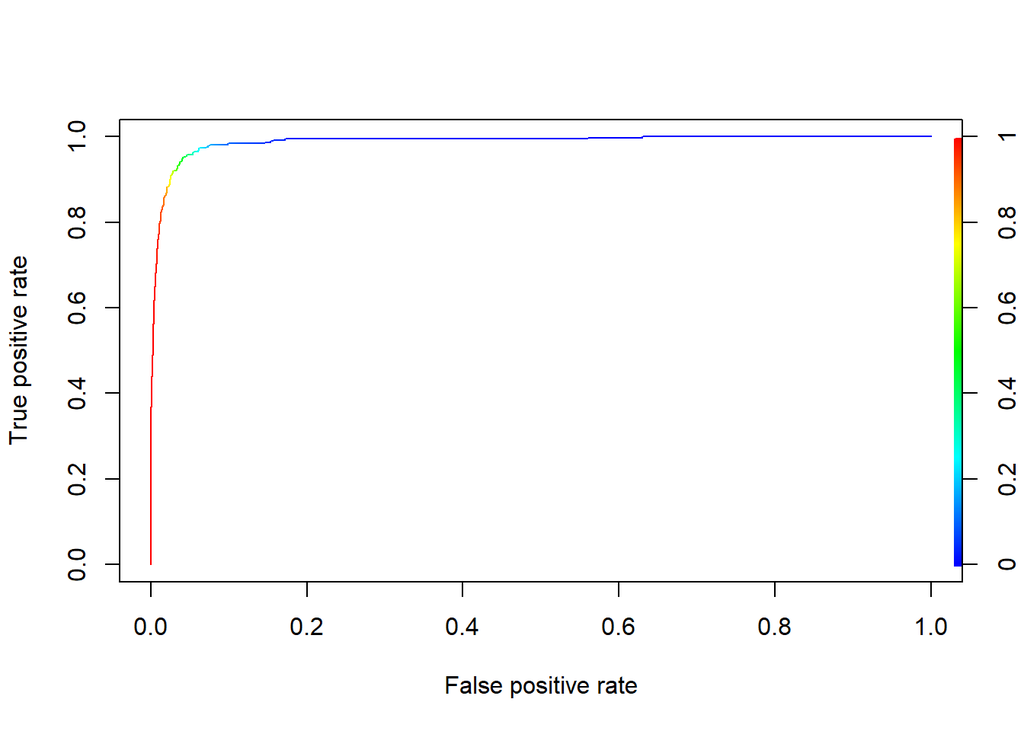

```r
#ROCR Curve
library(ROCR)
ROCRpred <- prediction(predict, test_log$class)
ROCRperf <- performance(ROCRpred, 'tpr','fpr')
plot(ROCRperf, colorize = TRUE, text.adj = c(-0.2,1.7))
```

```r
# AUC value
auc_ROCR <- performance(ROCRpred, measure = "auc")
auc_ROCR <- auc_ROCR@y.values[[1]];auc_ROCR
```

```
## [1] 0.9875581
```

### 5.4.3 Regresión logística, imputación mediana, datos transformados Box-Cox y con datos balanceados mediante pesos

Se continúa este caso con datos transformados Box-Cox con imputación por mediana. Balanceado de datos con Weights, de forma que el peso de todos los negativos es 0.5 y todos los positivos es 0.5 (suma total de pesos igual a 1). El hecho de incrementar el peso de los positivos hace que el modelo resultante sea más sensible al error de falso negativo. En este caso ninguna de las variables predictoras resulta ser significativa, si bien el modelo se ajusta bien a los datos de testeo y el coste total es muy bajo. Sin embargo, que ninguna variable predictora resulte ser significativa es un mal resultado. EL número de iteraciones para llegar al resultado ha sido 12 y el AIC final de 258. El coste total es 16650.

Si en vez de utilizar los datos transformados Box-Cox se utilizan los datos sin transformar, al modelo le cuesta converger (número de iteraciones máximo impuesto 100) y resulta que las 129 variables son significativas, hecho que tampoco es deseble.

Se muestra la ejecución con datos transformados Box-Cox.

```r
train_log<-train_bc_median
test_log<-test_bc_median
train_log$class[train_log$class=="neg"]<-"0"
train_log$class[train_log$class=="pos"]<-"1"
train_log$class<-as.factor(train_log$class)
levels(train_log$class)<- c('neg', 'pos')

summary(train_log$class)
```

```
##   neg   pos
## 58650   996
```

```r
# Create model weights (they sum to one)

model_weights <- ifelse(train_log$class == "neg",
                        (1/table(train_log$class)[1]) * 0.5,
                        (1/table(train_log$class)[2]) * 0.5)
summary(train_log$class)
```

```
##   neg   pos
## 58650   996
```

```r
sum(model_weights)
```

```
## [1] 1
```

```r
library(caret)
ctrl<-glm.control(epsilon = 1e-8, maxit =100, trace = FALSE)
model_log3 <- glm (class~.,data=train_log, weights=model_weights,family = binomial,control=ctrl)
summary(model_log3)
```

```
##
## Call:
## glm(formula = class ~ ., family = binomial, data = train_log,
##     weights = model_weights, control = ctrl)
##
## Deviance Residuals:
##       Min         1Q     Median         3Q        Max
## -0.017096  -0.000702  -0.000283  -0.000055   0.084759
##
## Coefficients:
##               Estimate Std. Error z value Pr(>|z|)
## (Intercept) -2.434e+01  1.916e+02  -0.127    0.899
## aa_000       2.088e-01  9.395e+00   0.022    0.982
## ac_000       4.183e-02  1.780e+00   0.023    0.981
## ag_000       1.205e-01  9.128e+00   0.013    0.989
## ag_002      -8.790e-02  3.972e+00  -0.022    0.982
## ag_004      -4.854e-02  8.407e+00  -0.006    0.995
## ag_005      -5.510e-01  1.223e+01  -0.045    0.964
## ag_006       8.947e-02  1.403e+01   0.006    0.995
## ag_007      -1.029e-01  7.443e+00  -0.014    0.989
## ag_008       4.468e-02  4.014e+00   0.011    0.991
## ag_009      -1.137e-01  2.447e+00  -0.046    0.963
## aj_000       6.444e-02  2.465e+00   0.026    0.979
## al_000      -7.827e-02  1.091e+01  -0.007    0.994
## am_0         1.011e-02  1.023e+01   0.001    0.999
## an_000      -1.382e+00  6.443e+01  -0.021    0.983
## ao_000       9.539e-01  5.016e+01   0.019    0.985
## ap_000       3.607e+00  5.833e+01   0.062    0.951
## aq_000       1.337e+00  3.070e+01   0.044    0.965
## ar_000      -3.228e-01  1.162e+01  -0.028    0.978
## as_000      -4.818e-02  1.635e+01  -0.003    0.998
## at_000       1.202e-02  2.404e+00   0.005    0.996
## au_000       1.590e-01  1.383e+01   0.011    0.991
## av_000       4.298e-01  9.024e+00   0.048    0.962
## ax_000      -6.101e-01  1.012e+01  -0.060    0.952
## ay_000       3.794e-01  7.641e+00   0.050    0.960
## ay_001      -5.028e-01  1.411e+01  -0.036    0.972
## ay_002       5.787e-01  1.304e+01   0.044    0.965
## ay_003      -1.846e-01  7.170e+00  -0.026    0.979
## ay_004       4.261e-02  3.168e+00   0.013    0.989
```

[output cut: 93 more lines]

```
## ee_005       1.401e-01  1.490e+01   0.009    0.992
## ee_006       4.285e-01  9.790e+00   0.044    0.965
## ee_007      -3.625e-01  7.938e+00  -0.046    0.964
## ee_008       1.713e-01  6.746e+00   0.025    0.980
## ee_009      -4.409e-02  2.928e+00  -0.015    0.988
## ef_000       1.933e-01  5.006e+01   0.004    0.997
## eg_000       1.742e-01  3.998e+01   0.004    0.997
##
## (Dispersion parameter for binomial family taken to be 1)
##
##     Null deviance: 1.38629  on 59645  degrees of freedom
## Residual deviance: 0.22965  on 59517  degrees of freedom
## AIC: 258
##
## Number of Fisher Scoring iterations: 12
```

```r
# Mostrar las variables significativas (p<0.05)
sig_coeff3<-data.frame(summary(model_log3)$coef[summary(model_log3)$coef[,4] <= .05,c(4)])
names(sig_coeff3)<-c("p_value")
dim(sig_coeff3)[1]
```

```
## [1] 0
```

```r
rownames(sig_coeff3)
```

```
## character(0)
```

```r
## Predicción de valores
predict <- predict(model_log3, test_log, type = 'response')

## Matriz de confusión
cm<-table(test_log$class, predict > 0.5)
cm
```

```
##
##       FALSE  TRUE
##   neg 15010   615
##   pos    21   354
```

```r
precision<-(cm[1,1]+cm[2,2])/sum(cm);precision
```

```
## [1] 0.96025
```

```r
## Coste Total
coste_total_log <- cm[1,2]*10 + cm[2,1]*500
coste_total_log
```

```
## [1] 16650
```

```r
# AUC value
auc_ROCR <- performance(ROCRpred, measure = "auc")
auc_ROCR <- auc_ROCR@y.values[[1]];auc_ROCR
```

```
## [1] 0.9875581
```

```r
train_log<-NULL
test_log<-NULL
```

## 5.5 Naive Bayes

```r
if (!require("e1071")) install.packages("e1071")
library(e1071) # Naive Bayes en este paquete
if (!require("ROSE")) install.packages("ROSE")
library(ROSE) # ROSE para balanceado


# ModeloS
train_balanced <- ROSE(class ~ ., data=train_bc_km)$data
train_balanced$class<-as.factor(train_balanced$class)
test_nb<-test_bc_km
test_nb$class<-as.factor(test_nb$class)

model_nb <- naiveBayes(class ~ ., data = train_balanced)
#model_nb
summary(model_nb)
```

```
##           Length Class  Mode
## apriori     2    table  numeric
## tables    128    -none- list
## levels      2    -none- character
## isnumeric 128    -none- logical
## call        4    -none- call
```

```r
## Predicción de valores
prediction <- predict(model_nb, as.data.frame(test_nb))

## Matriz de confusión
cm <- table(test_nb$class,prediction)
cm
```

```
##      prediction
##         neg   pos
##   neg 14760   865
##   pos    39   336
```

```r
cm_stat<-confusionMatrix(cm,positive="pos")
cm_stat
```

```
## Confusion Matrix and Statistics
##
##      prediction
##         neg   pos
##   neg 14760   865
##   pos    39   336
##
##                Accuracy : 0.9435
##                  95% CI : (0.9398, 0.947)
##     No Information Rate : 0.9249
##     P-Value [Acc > NIR] : < 2.2e-16
##
##                   Kappa : 0.4051
##
##  Mcnemar's Test P-Value : < 2.2e-16
##
##             Sensitivity : 0.27977
##             Specificity : 0.99736
##          Pos Pred Value : 0.89600
##          Neg Pred Value : 0.94464
##              Prevalence : 0.07506
##          Detection Rate : 0.02100
##    Detection Prevalence : 0.02344
##       Balanced Accuracy : 0.63857
##
##        'Positive' Class : pos
##
```

```r
precision<-(cm[1,1]+cm[2,2])/sum(cm);precision
```

```
## [1] 0.9435
```

```r
## Coste Total
coste_total_nb <- cm[1,2]*10 + cm[2,1]*500
coste_total_nb
```

```
## [1] 28150
```

## 5.6 Resumen de resultados

El mejor resultado se ha obtenido con la regresión logística, utilizando la técnica SMOTE para balancear los datos. Si bien los resultados han sido mejores con el balanceo por pesos, el modelo resultado ha obtenido 0 variables significativas, lo que no es admisible. Cabe destacar cómo han reducido los falsos negativos al balancear los datos con SMOTE, ya que el problema de los algorimtos de clasificación es que tienden a favorecer la clase mayoritaria (si no se utiliza otra técnica para balancear casos).

Se resumen en la tabla los resultados obtenidos en los diferentes análisis:

[output not shown]

# 6 Conclusiones

El trabajo ha comenzado con la limpieza de datos y tratamiento de perdidos y ceros. El conjunto de datos de entrenamiento tiene un tamaño elevado, por lo que se han utilizado técnicas exploratorias para adquirir de forma ágil información de todas las variables. El conjunto de datos original incluía un alto número de perdidos (169 columnas de 171 presentaban algún valor perdido). Se han eliminado columnas con perdidos superiores al 20% (24 variables). Para el resto de datos perdidos, se ha optado por la función ClustImpute (función ClustImpute) que realiza una función por cluster k-means. También se ha utilizado la imputación más habitual por la mediana y comparado más adelante en la fase de análisis los resultados de ambas imputaciones. Como se ha comentado, no ha resultado posible la imputación con missForest, debido al gran tamaño de la muestra (se ha realizado un ejemplo con una muestra menor con resultado satisfactorio). Para terminar con la fase de preprocesamiento, se ha utilizado también el Análisis de Componentes Principales, sí que se ha obtenido una reducción considerable ( 50% de variables para explicar el 95% de la varianza ) del número de variables, aunque el número de variables sigue siendo elevado. Los datos no presentaban una distribución normal. Se ha optado por una transformación Box-Cox logística (lamda=0) para mejorar su semejanza en la normal, pero en los casos de muchos ceros la distribución ha seguido teniendo una distribución diferente a la normal.

En la fase de análisis, se han utilizado el árbol de decisión c5.0, regresión logística y Naive Bayes, en diferentes escenarios. El mejor resultado se ha obtenido con la regresión logística, utilizando la técnica SMOTE para balancear los datos. Cabe destacar cómo se han reducido los falsos negativos al balancear los datos con SMOTE, ya que el problema de los algorimtos de clasificación es que tienden a favorecer la clase mayoritaria (si no se utiliza otra técnica para balancear casos). En el caso de Naive Bayes se ha utilizado el paquete ROSE para el balanceo de datos.

Por último, el principal reto de este conjunto de datos de SCANIA ha sido el gran tamaño del mismo (tanto número de filas como de columnas), seguido del desequilibrio entre las clases positivo y negativa. Para trabajar con grandes volúmenes de datos, es importante utilizar técnicas exploratorias (EDA, Exploratory Data Analysis) que nos permitan obtener información general de todas las variables de un “vistazo”, así como utilizar técnicas de análisis eficientes computacionalmente. Durante el trabajo hemos descubierto paquetes como skimr, ClustImpute, dlookr o NaiveBayes, que han facilitado nuestro análisis. El otro reto ha sido el desequilibrio entre las clases positivas y negativas, donde se han descubierto técnicas como SMOTE y ROSE que solucionan el problema mediantes upsampling, downsampling o “mixto”.

# 7 Contribuciones

Los autores de este trabajo Iván Jiménez (IJ) e Itziar Ricondo (IR) han contribuido en las diferentes fases del trabajo, como consta en las siguientes firmas.

| Contribuciones | Firma |
| --- | --- |
| Investigación previa | IJ,IR |
| Redacción de las respuestas | IJ,IR |
| Desarrollo de código | IJ,IR |

# 8 Referencias

[1] https://archive.ics.uci.edu/ml/datasets/APS+Failure+at+Scania+Trucks

[2] https://www.r-bloggers.com/2019/06/how-data-tables-fread-can-save-you-a-lot-of-time-and-memory-and-take-input-from-shell-commands/

[3] https://www.datanovia.com/en/blog/display-a-beautiful-summary-statistics-in-r-using-skimr-package/

[4] https://www.r-bloggers.com/2019/06/intoducing-clustimpute-a-new-approach-for-k-means-clustering-with-build-in-missing-data-imputation/

[5] https://rpubs.com/lmorgan95/MissForest

[6] https://www.rdocumentation.org/packages/DMwR/versions/0.4.1/topics/SMOTE

[7] https://rdrr.io/cran/naivebayes/